# Making a decision boundary plot

In this notebook, I will demonstrate how to make a decision boundary plot. This relies on two functions from the $\texttt{functions.R}$ file:

- $\texttt{calc_boundary}$, from which we obtain a decision boundary at level $\alpha$ for a given method.
- $\texttt{simulate_data}$, from which we simulate data according to Section 6.1.

The plot at the end of this notebook will be the same as the one shown in the faceted plot of Figure 9 for $\pi_{1} = 0.6$ and $\rho = 0.6$. By changing the values in $\texttt{simulate_data}$ accordingly, one can make the other plots as well.

First, we obtain the decision boundary for all methods and store their coordinates in $\texttt{results}$:

```r
source("functions.R")
set.seed(500851177)

df <- simulate_data(n = 1000, pi1 = 0.6, rho = 0.6, signal = 2.5, df = 2)

methods <- c("closedeBH", "closedBY", "closedSu", "medianTDP", "TDPbound")
results <- lapply(methods, function(m) calc_boundary(df, alpha = 0.05, method = m))
```

We then convert $\texttt{results}$ to a format that is compatible with the plotting functions in the $\texttt{ggplot2}$ library:

```r
plot_df <- do.call(rbind, lapply(seq_along(results), function(i) {
  data.frame(
    Method = methods[i],
    cx = results[[i]]$cx,
    cy = results[[i]]$cy,
    stringsAsFactors = FALSE
  )
}))

head(plot_df)
```

|  | Method | cx | cy |
| --- | --- | --- | --- |
| 1 | closedeBH | 1000 | 1 |
| 2 | closedeBH | 1000 | 2 |
| 3 | closedeBH | 1000 | 3 |
| 4 | closedeBH | 1000 | 4 |
| 5 | closedeBH | 1000 | 5 |
| 6 | closedeBH | 1000 | 6 |

The code above suffices to plot the decision boundaries. Optionally, the $\texttt{geom_raster}$ function of $\texttt{ggplot2}$ can be used if we want to add a heatmap to the background. Note that this can be computationally expensive for large data sets, as it requires a matrix that contains the set size of every coordinate using $\texttt{colCumsums}$ from the $\texttt{matrixStats}$ package. To circumvent this, we can downsample our matrix using $\texttt{target_res}$, which sets the number of bins in each dimension. In this example, the sample size is smaller than $\texttt{target_res}$ (1000 < 1500), so the matrix is not downsampled.

If $\pi_{1}$ and $\rho$ are changed, ensure that $\texttt{limit}$ is also updated, as it controls the upper bound of the y-axis in the plot.

```r
library(matrixStats)
library(reshape2)

rank_lf <- rank(-abs(df$log2FoldChange), ties.method = "first")
rank_p  <- rank(df$pvalue, ties.method = "first")

n <- nrow(df)
ind <- matrix(0, n, n)
ind[cbind(rank_lf, rank_p)] <- 1

max_cx <- max(sapply(results, function(x) max(x$cx)))
max_cy <- max(sapply(results, function(x) max(x$cy)))

target_res <- 1500

step_x <- max(1, floor(max_cx / target_res))
step_y <- max(1, floor((max_cy - 1) / target_res))

row_idx <- seq(1, max_cx, by = step_x)
col_idx <- seq(1, max_cy - 1, by = step_y)

lengths <- colCumsums(rowCumsums(ind))
lengths <- lengths[row_idx, col_idx]

background    <- melt(lengths, varnames = c("lf", "p"), value.name = "overlap")
background$lf <- row_idx[background$lf]
background$p  <- col_idx[background$p]

limit <- 500
background <- background[background$p <= 500, ]
```

From this, we can obtain the plot:

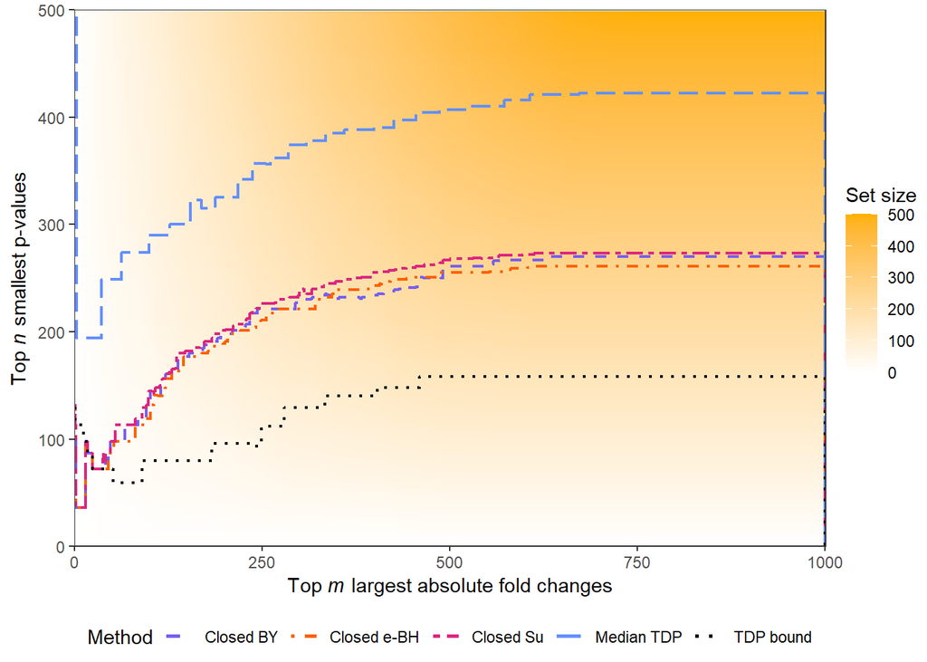

```r
library(ggplot2)

colours <- c(closedeBH = "#FE6100", closedBY = "#785EF0",
             closedSu = "#DC267F",  medianTDP = "#648FFF", TDPbound = "#000000")
linetps <- c(closedeBH = "dotdash", closedBY = "dashed",
             closedSu = "twodash", medianTDP = "longdash", TDPbound = "dotted")

ggplot() +
  geom_raster(data = background, aes(x = lf, y = p, fill = overlap)) +
  scale_fill_gradient(
    low = "#FFFFFF",
    high = "#FFB000",
    name = "Set size",
    guide = guide_colorbar(position = "right")
  ) +
  geom_path(
    data = plot_df,
    aes(x = cx, y = cy, color = Method, linetype = Method),
    linewidth = 0.75
  ) +
  scale_color_manual(
    values = colours,
    breaks = c("closedBY", "closedeBH", "closedSu", "medianTDP", "TDPbound"),
    labels = c("Closed BY", "Closed e-BH", "Closed Su", "Median TDP", "TDP bound")
  ) +
  scale_linetype_manual(
    values = linetps,
    breaks = c("closedBY", "closedeBH", "closedSu", "medianTDP", "TDPbound"),
    labels = c("Closed BY", "Closed e-BH", "Closed Su", "Median TDP", "TDP bound")
  ) +
  scale_x_continuous(expand = c(0, 0)) +
  scale_y_continuous(expand = c(0, 0), limits = c(0, limit)) +
  labs(
    x = expression(paste("Top ", italic("m"), " largest absolute fold changes")),
    y = expression(paste("Top ", italic("n"), " smallest p-values")),
    fill = "Set size"
  ) +
  theme_test() +
  theme(legend.position = "bottom") +
  guides(
    color = guide_legend(override.aes = list(linewidth = 1), position = "bottom"),
    linetype = guide_legend(position = "bottom")
  )
```

Interpreting the plot is simple: any discovery set positioned at or below a decision boundary is contained in the collection of valid discovery sets for that method. For example, the discovery set at the coordinate (500, 100) is a valid choice based on the closed methods, but the discovery set at the coordinate (500, 300) is not.

**Note:** I used the function $\texttt{facet_grid2}$ from the library $\texttt{ggh4x}$ to generate the faceted plot in Figure 9. The code that I wrote for this is mostly similar to the code above, with the key difference being that I used a nested for-loop to repeat everything for all combinations of $\pi_{1}$ and $\rho$. The resulting code is rather lengthy, hence why I decided to only demonstrate how to make a single plot.